# STA137 Project

2023-12-02

## Introduction

### Motivation

The increasing awareness of the significance of a healthy diet has led to a dramatic increase in the popularity of avocados, solidifying their status as a dietary staple. This surge in demand, however, has brought about an escalation in avocado prices. Besides, the unique growth requirements of avocados, plus their susceptibility to environmental conditions, contribute to the volatility in prices, presenting a substantial challenge for both producers and consumers. Therefore it is necessary to have a comprehensive understanding of the factors influencing their market dynamics.

### Problem Definition

As we delve into the time series analysis, there are several questions that we are interested in: - Trend Identification: What are the trends in avocado prices over the observed period? Are there any patterns or cycles? - Seasonal Variations: How do avocado prices fluctuate seasonally? Are there specific times of the year when prices tend to be higher or lower? - Cyclical Patterns: Are there any cyclical patterns in avocado prices that repeat over a certain time frame? - Forecasting: Can we build a reliable model to forecast future avocado prices based on historical data?

## Data Processing

```r
library(lubridate)
library(dplyr)
library(tidyr)
library(xts)
```

```r
library(ggplot2)
library(ggpmisc)
library(ggthemes)
library(zoo)
library(tseries)
library(tidyverse)
library(skimr)
library(GGally)
library(viridis)
library(tibbletime)
library(gridExtra)
setwd("/Users/janiceli/Desktop")
avocado = read.csv("avocado.csv")

# Change the category variable into factor
avocado$type = as.factor(avocado$type)
avocado$region = as.factor(avocado$region)
avocado$year = as.factor(avocado$year)
# Convert 'Date' to a Date object
avocado$Date <- as.Date(avocado$Date)

# Data statistics
str(avocado)
```

```
## 'data.frame':    18249 obs. of  14 variables:
##  $ X           : int  0 1 2 3 4 5 6 7 8 9 ...
##  $ Date        : Date, format: "2015-12-27" "2015-12-20" ...
##  $ AveragePrice: num  1.33 1.35 0.93 1.08 1.28 1.26 0.99 0.98 1.02 1.07 ...
##  $ Total.Volume: num  64237 54877 118220 78992 51040 ...
##  $ X4046       : num  1037 674 795 1132 941 ...
##  $ X4225       : num  54455 44639 109150 71976 43838 ...
##  $ X4770       : num  48.2 58.3 130.5 72.6 75.8 ...
##  $ Total.Bags  : num  8697 9506 8145 5811 6184 ...
##  $ Small.Bags  : num  8604 9408 8042 5677 5986 ...
##  $ Large.Bags  : num  93.2 97.5 103.1 133.8 197.7 ...
##  $ XLarge.Bags : num  0 0 0 0 0 0 0 0 0 0 ...
##  $ type        : Factor w/ 2 levels "conventional",..: 1 1 1 1 1 1 1 1 1 1 ...
##  $ year        : Factor w/ 4 levels "2015","2016",..: 1 1 1 1 1 1 1 1 1 1 ...
##  $ region      : Factor w/ 54 levels "Albany","Atlanta",..: 1 1 1 1 1 1 1 1 1 1 ...
```

```r
summary(avocado)
```

```
##        X              Date             AveragePrice    Total.Volume
##  Min.   : 0.00   Min.   :2015-01-04   Min.   :0.440   Min.   :      85
##  1st Qu.:10.00   1st Qu.:2015-10-25   1st Qu.:1.100   1st Qu.:   10839
##  Median :24.00   Median :2016-08-14   Median :1.370   Median :  107377
##  Mean   :24.23   Mean   :2016-08-13   Mean   :1.406   Mean   :  850644
##  3rd Qu.:38.00   3rd Qu.:2017-06-04   3rd Qu.:1.660   3rd Qu.:  432962
##  Max.   :52.00   Max.   :2018-03-25   Max.   :3.250   Max.   :62505647
##
##      X4046              X4225              X4770           Total.Bags
##  Min.   :       0   Min.   :       0   Min.   :      0   Min.   :       0
##  1st Qu.:     854   1st Qu.:    3009   1st Qu.:      0   1st Qu.:    5089
##  Median :    8645   Median :   29061   Median :    185   Median :   39744
##  Mean   :  293008   Mean   :  295155   Mean   :  22840   Mean   :  239639
##  3rd Qu.:  111020   3rd Qu.:  150207   3rd Qu.:   6243   3rd Qu.:  110783
##  Max.   :22743616   Max.   :20470573   Max.   :2546439   Max.   :19373134
##
##    Small.Bags         Large.Bags       XLarge.Bags                 type
##  Min.   :       0   Min.   :      0   Min.   :     0.0   conventional:9126
##  1st Qu.:    2849   1st Qu.:    127   1st Qu.:     0.0   organic     :9123
##  Median :   26363   Median :   2648   Median :     0.0
##  Mean   :  182195   Mean   :  54338   Mean   :  3106.4
##  3rd Qu.:   83338   3rd Qu.:  22029   3rd Qu.:   132.5
##  Max.   :13384587   Max.   :5719097   Max.   :551693.7
##
##    year                      region
##  2015:5615   Albany             :  338
##  2016:5616   Atlanta            :  338
##  2017:5722   BaltimoreWashington:  338
##  2018:1296   Boise              :  338
##              Boston             :  338
##              BuffaloRochester   :  338
##              (Other)            :16221
```

```r
# Check the NA value
any(is.na(avocado))
```

```
## [1] FALSE
```

```r
# There is no NA values.

avocado_con = avocado[avocado$type == "conventional",]
avocado_org = avocado[avocado$type == "organic",]

# Resampling the data into weekly frequency
avocado1 <- avocado %>%
  group_by(Date = format(Date, "%Y-%m-%d")) %>%
  summarise(AveragePrice = mean(AveragePrice))

# Resampling the data into weekly frequency
avocado_con_weekly <- avocado_con %>%
  group_by(Date = format(Date, "%Y-%m")) %>%
  summarise(AveragePrice = mean(AveragePrice))

# Resampling the data into weekly frequency
avocado_org_weekly <- avocado_org %>%
  group_by(Date = format(Date, "%Y-%m")) %>%
  summarise(AveragePrice = mean(AveragePrice))

org <- avocado %>% dplyr::select(Date, AveragePrice, type, Total.Volume, year) %>% filter(type == "organic")
con <- avocado %>% dplyr::select(Date, AveragePrice, type, Total.Volume, year) %>% filter(type == "conventional")
```

## Data Description

The dataset avocado contains 18249 observations with 14 variables. Since our goal is to analyze and predict the price between conventional and organic avocado, we will only keep the necessary variables as followed: - Date: the data of the observation, Recorded as YYYY-MM-DD through 2015-01-04 to 2018-03-25. - AveragePrice: the average price of a single avocado - type: conventional or organic - year: the observation year

## EDA

First we separate the dataset into two categories by their types and then check their distribution and quanties.

```r
# Histogram for Average Price
#hist(avocado$AveragePrice)
#hist(avocado_monthly$AveragePrice)
#hist(avocado_weekly$AveragePrice)

summary(avocado)
```

```
##        X              Date             AveragePrice    Total.Volume
##  Min.   : 0.00   Min.   :2015-01-04   Min.   :0.440   Min.   :      85
##  1st Qu.:10.00   1st Qu.:2015-10-25   1st Qu.:1.100   1st Qu.:   10839
##  Median :24.00   Median :2016-08-14   Median :1.370   Median :  107377
##  Mean   :24.23   Mean   :2016-08-13   Mean   :1.406   Mean   :  850644
##  3rd Qu.:38.00   3rd Qu.:2017-06-04   3rd Qu.:1.660   3rd Qu.:  432962
##  Max.   :52.00   Max.   :2018-03-25   Max.   :3.250   Max.   :62505647
##
##      X4046              X4225              X4770           Total.Bags
##  Min.   :       0   Min.   :       0   Min.   :      0   Min.   :       0
##  1st Qu.:     854   1st Qu.:    3009   1st Qu.:      0   1st Qu.:    5089
##  Median :    8645   Median :   29061   Median :    185   Median :   39744
##  Mean   :  293008   Mean   :  295155   Mean   :  22840   Mean   :  239639
##  3rd Qu.:  111020   3rd Qu.:  150207   3rd Qu.:   6243   3rd Qu.:  110783
##  Max.   :22743616   Max.   :20470573   Max.   :2546439   Max.   :19373134
##
##    Small.Bags         Large.Bags       XLarge.Bags                 type
##  Min.   :       0   Min.   :      0   Min.   :     0.0   conventional:9126
##  1st Qu.:    2849   1st Qu.:    127   1st Qu.:     0.0   organic     :9123
##  Median :   26363   Median :   2648   Median :     0.0
##  Mean   :  182195   Mean   :  54338   Mean   :  3106.4
##  3rd Qu.:   83338   3rd Qu.:  22029   3rd Qu.:   132.5
##  Max.   :13384587   Max.   :5719097   Max.   :551693.7
##
##    year                      region
##  2015:5615   Albany             :  338
##  2016:5616   Atlanta            :  338
##  2017:5722   BaltimoreWashington:  338
##  2018:1296   Boise              :  338
##              Boston             :  338
##              BuffaloRochester   :  338
##              (Other)            :16221
```

```r
summary(avocado_con)
```

```
##        X              Date             AveragePrice    Total.Volume
##  Min.   : 0.00   Min.   :2015-01-04   Min.   :0.460   Min.   :   33700
##  1st Qu.:10.00   1st Qu.:2015-10-25   1st Qu.:0.980   1st Qu.:  198909
##  Median :24.00   Median :2016-08-14   Median :1.130   Median :  408326
##  Mean   :24.24   Mean   :2016-08-14   Mean   :1.158   Mean   : 1653213
##  3rd Qu.:38.00   3rd Qu.:2017-06-04   3rd Qu.:1.320   3rd Qu.: 1030992
##  Max.   :52.00   Max.   :2018-03-25   Max.   :2.220   Max.   :62505647
##
##      X4046              X4225              X4770             Total.Bags
##  Min.   :      72   Min.   :    1518   Min.   :      0.0   Min.   :    3047
##  1st Qu.:   31935   1st Qu.:   50919   1st Qu.:    556.9   1st Qu.:   57248
##  Median :  104707   Median :  136115   Median :   6035.9   Median :   98897
##  Mean   :  578612   Mean   :  574805   Mean   :  45405.8   Mean   :  454390
##  3rd Qu.:  364717   3rd Qu.:  415170   3rd Qu.:  21181.8   3rd Qu.:  291696
##  Max.   :22743616   Max.   :20470573   Max.   :2546439.1   Max.   :19373134
##
##    Small.Bags         Large.Bags       XLarge.Bags                 type
##  Min.   :    1119   Min.   :      0   Min.   :     0.0   conventional:9126
##  1st Qu.:   43296   1st Qu.:   2308   1st Qu.:     0.0   organic     :   0
##  Median :   75727   Median :  14583   Median :   122.3
##  Mean   :  346722   Mean   : 101458   Mean   :  6210.6
##  3rd Qu.:  204397   3rd Qu.:  59911   3rd Qu.:  2409.2
##  Max.   :13384587   Max.   :5719097   Max.   :551693.7
##
##    year                      region
##  2015:2808   Albany             : 169
##  2016:2808   Atlanta            : 169
##  2017:2862   BaltimoreWashington: 169
##  2018: 648   Boise              : 169
##              Boston             : 169
##              BuffaloRochester   : 169
##              (Other)            :8112
```

```r
summary(avocado_org)
```

```
##        X              Date             AveragePrice    Total.Volume
##  Min.   : 0.00   Min.   :2015-01-04   Min.   :0.440   Min.   :     84.6
##  1st Qu.:10.00   1st Qu.:2015-10-25   1st Qu.:1.420   1st Qu.:   4779.9
##  Median :24.00   Median :2016-08-14   Median :1.630   Median :  10835.8
##  Mean   :24.23   Mean   :2016-08-13   Mean   :1.654   Mean   :  47811.2
##  3rd Qu.:38.00   3rd Qu.:2017-06-04   3rd Qu.:1.870   3rd Qu.:  30087.0
##  Max.   :52.00   Max.   :2018-03-25   Max.   :3.250   Max.   :1814930.0
##
##      X4046              X4225              X4770            Total.Bags
##  Min.   :     0.0   Min.   :     0.0   Min.   :    0.00   Min.   :      0
##  1st Qu.:   157.9   1st Qu.:   675.6   1st Qu.:    0.00   1st Qu.:   1686
##  Median :   911.5   Median :  3082.6   Median :    0.00   Median :   5096
##  Mean   :  7311.3   Mean   : 15411.9   Mean   :  266.25   Mean   :  24818
##  3rd Qu.:  4354.4   3rd Qu.:  9880.2   3rd Qu.:   30.27   3rd Qu.:  14380
##  Max.   :361996.8   Max.   :680037.4   Max.   :26765.78   Max.   :1124622
##
##    Small.Bags         Large.Bags        XLarge.Bags                type
##  Min.   :     0.0   Min.   :     0.0   Min.   :  0.000   conventional:   0
##  1st Qu.:   776.6   1st Qu.:     4.4   1st Qu.:  0.000   organic     :9123
##  Median :  2863.3   Median :   387.6   Median :  0.000
##  Mean   : 17613.5   Mean   :  7203.0   Mean   :  1.197
##  3rd Qu.:  9962.6   3rd Qu.:  2991.8   3rd Qu.:  0.000
##  Max.   :944572.5   Max.   :561530.4   Max.   :510.410
##
##    year                      region
##  2015:2807   Albany             : 169
##  2016:2808   Atlanta            : 169
##  2017:2860   BaltimoreWashington: 169
##  2018: 648   Boise              : 169
##              Boston             : 169
##              BuffaloRochester   : 169
##              (Other)            :8109
```

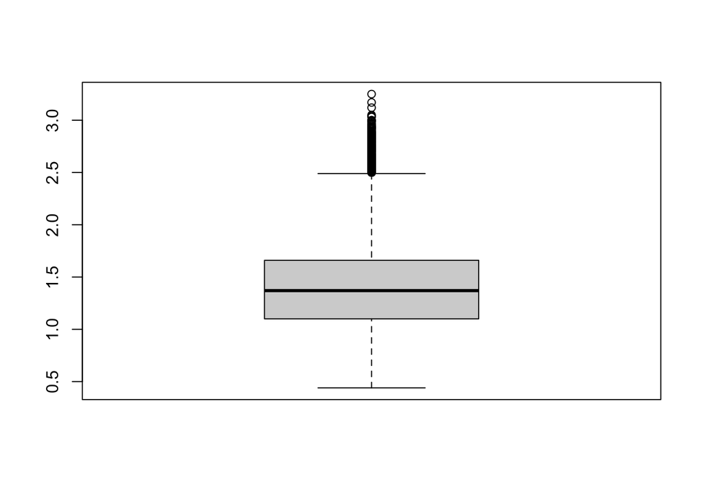

```r
# Outlier checking
boxplot(avocado$AveragePrice)
```

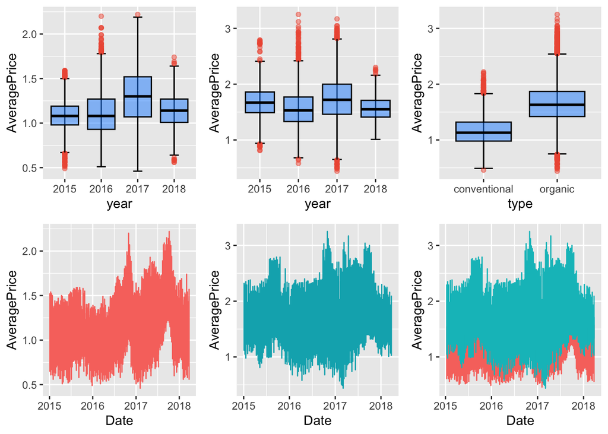

```r
# Set up the layout for the plots in one line
par(mfrow = c(3,3))
# Plot 1: Conventional Avocado Prices Each Year
p1 <- ggplot(avocado_con, aes(x = year, y = AveragePrice)) +
  stat_boxplot(geom = "errorbar", width = 0.25) +
  geom_boxplot(fill = "dodgerblue1", colour = "black", alpha = 0.5, outlier.colour = "tomato2")


# Plot 2: Organic Avocado Prices Each Year
p2 <- ggplot(avocado_org, aes(x = year, y = AveragePrice)) +
  stat_boxplot(geom = "errorbar", width = 0.25) +
  geom_boxplot(fill = "dodgerblue1", colour = "black", alpha = 0.5, outlier.colour = "tomato2")


# Plot 3: Two Types of Avocado Prices (Total)
p3 <- ggplot(avocado, aes(x = type, y = AveragePrice)) +
  stat_boxplot(geom = "errorbar", width = 0.25) +
  geom_boxplot(fill = "dodgerblue1", colour = "black", alpha = 0.5, outlier.colour = "tomato2")


# Check the distribution of two avocado prices
#p4 = ggplot(avocado, aes(x = AveragePrice, fill = type)) +
  #geom_density(alpha = 0.5)


avocado1 <- avocado[avocado$Date > as.Date("2015-01-04"), ] %>%
  filter(type == "conventional" | type == "organic")


p5=ggplot(avocado_con, aes(x = Date, y = AveragePrice, color = type)) +
  geom_line() +
  theme(legend.position = "none")

p6=ggplot(avocado_org, aes(x = Date, y = AveragePrice, color = type)) +
  geom_line(color = "#00AFBB") +
  theme(legend.position = "none")

p7=ggplot(avocado1, aes(x = Date, y = AveragePrice, color = type)) +
  geom_line() +
  theme(legend.position = "none")


# Arrange the plots in one line using grid.arrange
grid.arrange( p1, p2, p3, p5, p6, p7,  ncol = 3)
```

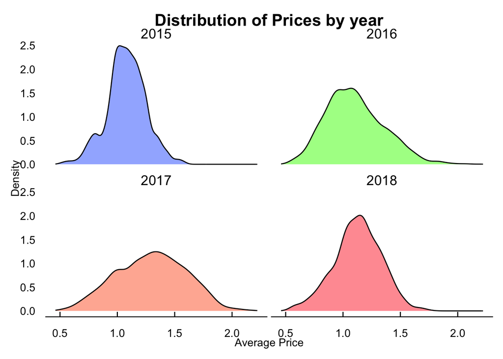

```r
# # Let's see if there are seasonal patterns with conventional avocadoes
ggplot(con, aes(x = AveragePrice, fill = as.factor(year))) +
  geom_density(alpha = .5) +
  theme_economist() +
  facet_wrap(~ year) + theme(plot.title=element_text(hjust=0.5), plot.background=element_rect(fill="white")) +
  guides(fill = FALSE) + labs(title="Distribution of Prices by year", x = 'Average Price', y = 'Density') +
  scale_fill_manual(values=c("#2E64FE", "#40FF00", "#FE642E", "#FE2E2E"))
```

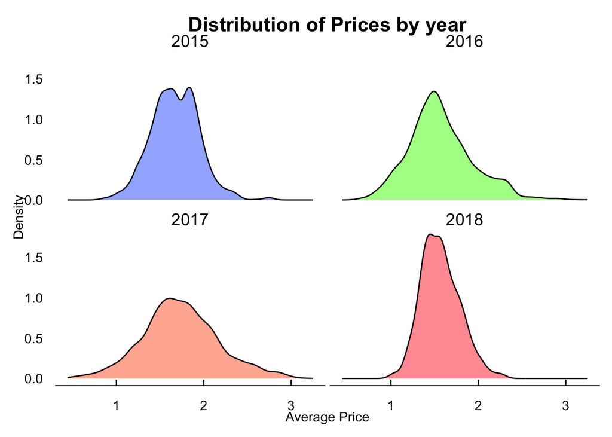

```r
# # Let's see if there are seasonal patterns with organice avocadoes
ggplot(org, aes(x = AveragePrice, fill = as.factor(year))) +
  geom_density(alpha = .5) +
  theme_economist() +
  facet_wrap(~ year) + theme(plot.title=element_text(hjust=0.5), plot.background=element_rect(fill="white")) +
  guides(fill = FALSE) + labs(title="Distribution of Prices by year", x = 'Average Price', y = 'Density') +
  scale_fill_manual(values=c("#2E64FE", "#40FF00", "#FE642E", "#FE2E2E"))
```

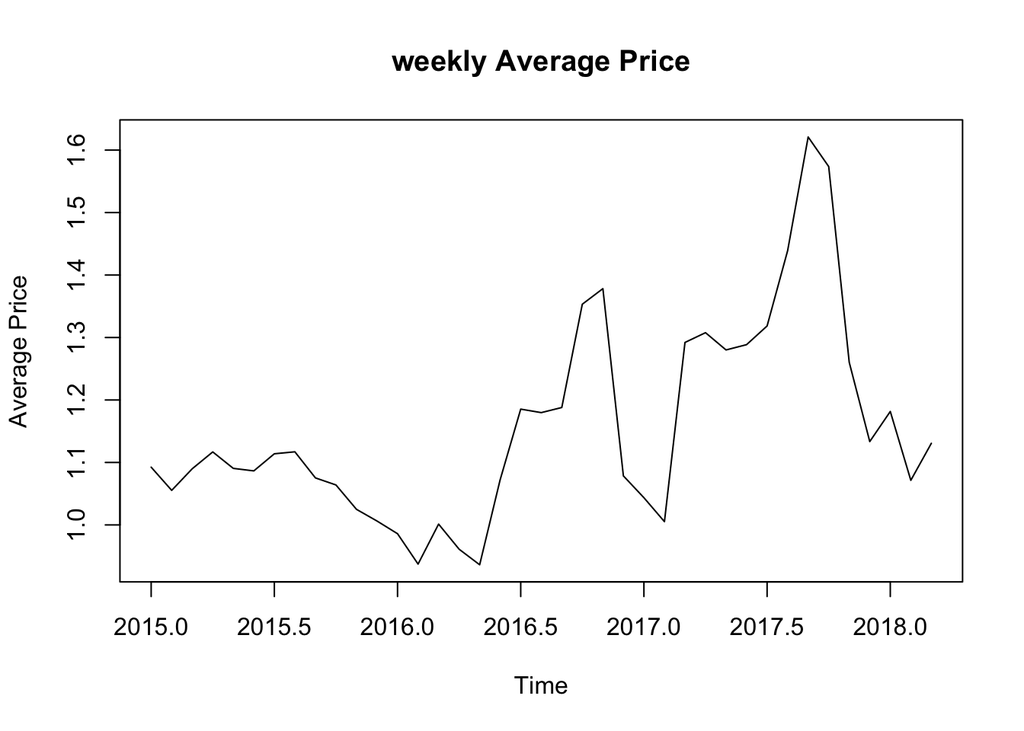

```r
# Time series plot by weekly average avocado price
avocado_con_ts_weekly <- ts(avocado_con_weekly$AveragePrice, start = 2015, frequency = 12)
ts.plot(avocado_con_ts_weekly, xlab = "Time", ylab = "Average Price", main = "weekly Average Price")

# Time series plot by weekly average avocado price
avocado_org_ts_weekly <- ts(avocado_con_weekly$AveragePrice, start = 2015, frequency = 12)
ts.plot(avocado_con_ts_weekly, xlab = "Time", ylab = "Average Price", main = "weekly Average Price")
```

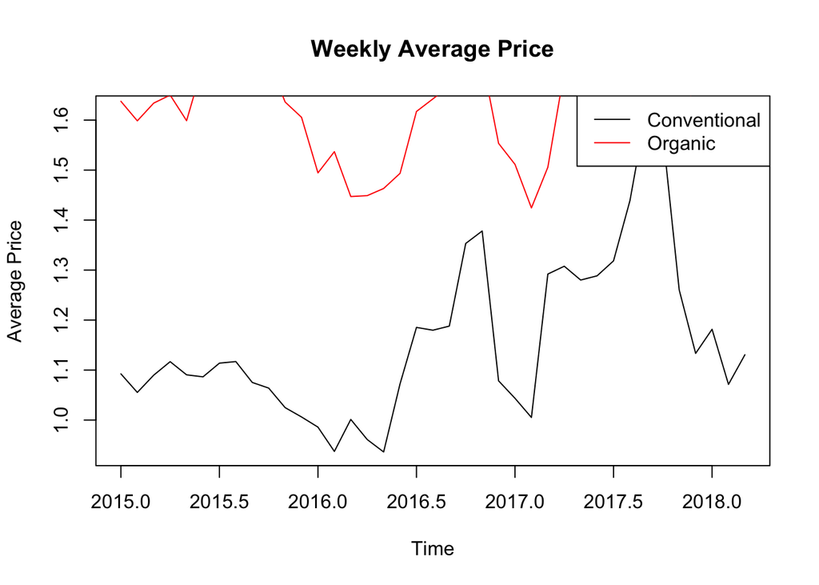

```r
# Create time series objects
avocado_con_ts_weekly <- ts(avocado_con_weekly$AveragePrice, start = 2015, frequency = 12)
avocado_org_ts_weekly <- ts(avocado_org_weekly$AveragePrice, start = 2015, frequency = 12)

# Plot the first time series
ts.plot(avocado_con_ts_weekly, xlab = "Time", ylab = "Average Price", main = "Weekly Average Price")
# Add the second time series to the plot
lines(avocado_org_ts_weekly, col = "red")
# Add a legend
legend("topright", legend = c("Conventional", "Organic"), col = c("black", "red"), lty = 1)
```